# Overview

This notebook provides a brief overview of the purpose and functionality of `mwarp1d` using the following three repository scripts, which are run inline in this notebook.

1. fig_dataset.py
2. fig_landmarks.py
3. fig_warp_overview.py

Running this notebook and/or the scripts will test all main `mwarp1d` functionality.

For detailed use instructions, refer to `mwarp1d`'s [online documentation](http://www.spm1d.org/mwarp1d/index.html).

### Example dataset

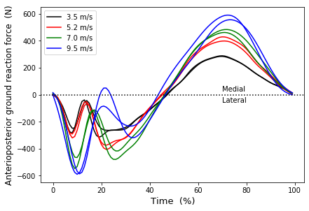

```python
%matplotlib inline

%run fig_dataset.py
```

**Figure 1**. Example dataset: anteroposterior (i.e., fore-aft) ground reaction forces when running at different speeds (Dorn et al. 2012). Local minima and maxima are not temporally aligned in the region: time = 10% to 25%, implying that [nonlinear warping](https://en.wikipedia.org/wiki/Image_warping) may improve registration.

### Example landmark warping

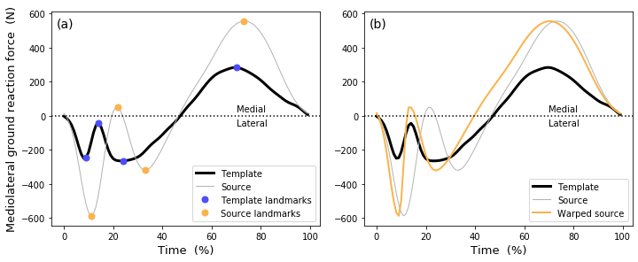

```python
%run fig_landmarks.py
```

**Figure 2**. Example landmark warping and registration. The registration goal is to warp the Source so that it becomes better aligned with the Template. (a) Landmark time nodes selected at local extrema. (b) Piecewise interpolation between source landmarks yields a warped source with qualitatively improved registration.

### Example manual warping

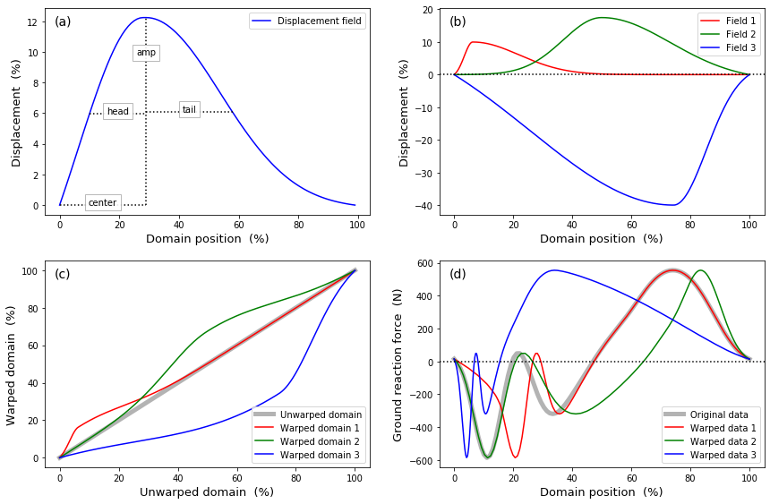

```python
%run fig_warp_overview.py
```

**Figure 3**. (a) Manual warp parameters: `center`, `amp` (amplitude), `head` and `tail`. Data at position `center` will be translated horizontally with an approximate magnitude of `amp`, where `head` and `tail` determine translation effect fall-off, or the translation effects on neighboring regions. (b) Three example warp kernels (i.e., displacement fields). (c) Corresponding warped domains. (d) Corresponding warped data for a single 1D measurement from Fig.1.

### Summary

`mwarp1d` allows users to nonlinearly register 1D data using either (1) landmark warping or (2) manual warping. This can be achieved via scripting, as demonstrated above, or using the `mwarp1d` GUI, as described in a series of [screencasts](http://www.spm1d.org/mwarp1d/quickstart.html).

### References

Dorn TW, Schache AG, Pandy MG (2012). “Muscular strategy shift in human running: de- pendence of running speed on hip and ankle muscle performance.” Journal of Experimental Biology, 215(11), 1944–1956. https://simtk.org/home/runningspeeds.